# Etude des résultats du second tour des élections présidentielles de 2022

Réalisé par : AZEHOUN Houéfa & CELMETA Nevina L3 Economie, Université de Tours

# Objectifs de l’étude :

L’objectif principal de ce projet est de faire une analyse comparative des résultats du deuxième tour des élections présidentielles de 2022 opposant **Emmanuel Macron** à **Marine Le Pen**. Cette étude intégréra aussi l’analyse des taux de participation.

## 1. Préparation de la base de données

Pour mener à bien notre étude, nous allons utiliser certains packages de **R**, comme *kableExtra*, *dplyr*, *tidyr*, *readr*, *knitr* et *ggplot2*, qui permettent le traitement et la manipulation des bases de données ainsi la construction des tableaux dynamiques et des graphiques.

La base de données que nous utilisons pour notre analyse porte sur les résultats généraux dans les bureaux de vote du second tour des élections présidentielles de 2022 en France. Elle est disponible sur le site suivant : [data.gouv](https://www.data.gouv.fr/fr/datasets/election-presidentielle-des-10-et-24-avril-2022-resultats-definitifs-du-2nd-tour/). Nous avons effectué un premier retraitement en rajoutant dans excel les noms des sept dernières colonnes. Ensuite, pour faciliter l’exploitation de la base nous avons choisir de renommer certaines colonnes. Cette base contient **69 682 lignes** correspondant au nombre de bureaux de vote et **35 colonnes** dont les nombres d’inscrits et d’abstentions, les votes exprimés et blancs ainsi que les communes et départements.

## 2. Analyse descriptive des données électorales

### 2.1 Taux d’abstention au niveau national

Le diagramme ci-dessous présente la répartition des votes au niveau national :

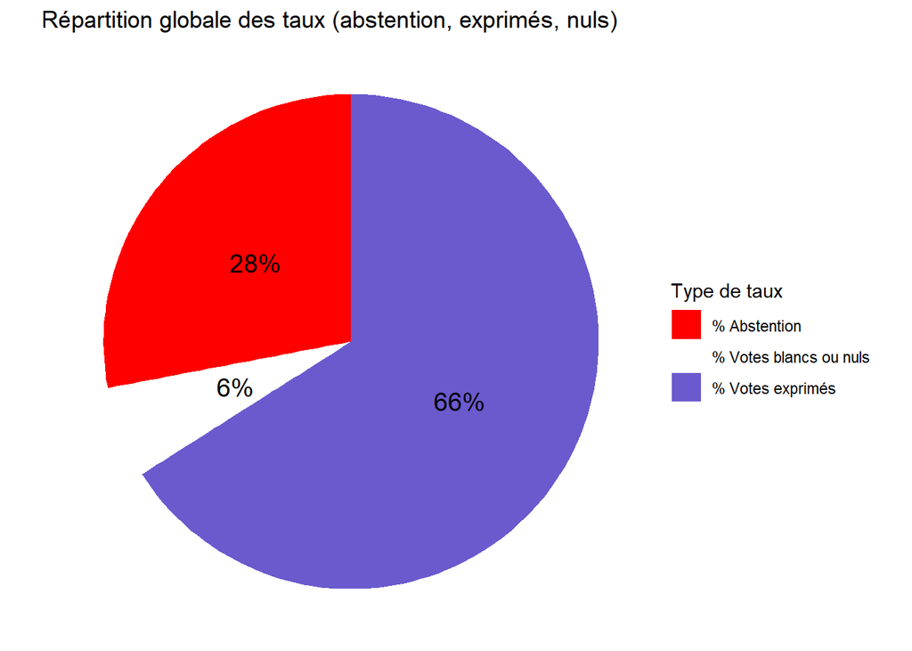

Le taux d’abstention au second tour des élections présidentielles s’élève à 28 %, un niveau historique pour ce type de scrutin, comme l’indique cet [article](https://www.lemonde.fr/politique/article/2022/04/25/les-resultats-du-second-tour-de-la-presidentielle-si-abstention-et-votes-blancs-et-nuls-etaient-pris-en-compte_6123552_823448.html) du journal *Le Monde*. Seuls **66 %** des inscrits ont voté pour l’un des deux candidats en lice.

### 2.2 Statistique des votes

Nous présentons ci-dessous quelques statistiques descriptives concernant les choix des votants.

| Statistique | Statistique des votes % Votes Exprimés | Statistique des votes % Votes Blancs | Statistique des votes % Votes Nuls |
| --- | --- | --- | --- |
| Minimum | 85.790 | 1.710 | 0.630 |
| 1er quartile | 89.635 | 5.805 | 2.025 |
| Médiane | 90.920 | 6.660 | 2.370 |
| 3ème quartile | 91.880 | 7.355 | 3.120 |
| Maximum | 97.260 | 9.670 | 6.030 |

On remarque que plus de **85% des votants** ont choisi l’un des deux candidats, quel que soit le département, et qu’il n’existe aucun département où plus de **plus de 10% des votants** ont délibérément choisi de ne pas accorder leur voix à l’un des candidats. En ce qui concerne les bulletins invalides (nuls), leur nombre ne dépasse pas **6**, peu importe le département.

### 2.3 Test de corrélation entre taux de participation et votes Blancs

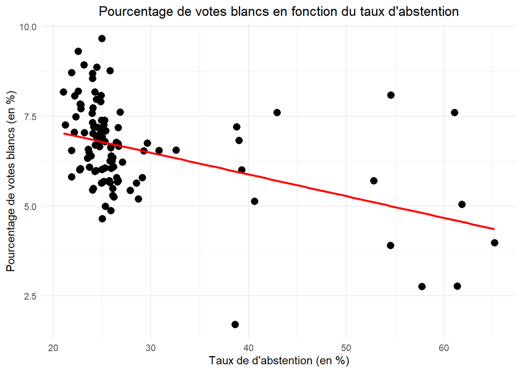

On observe une **corrélation négative (-0.44)** entre le **taux d’abstention** rapporté au nombre d’inscrits et le **pourcentage de vote blanc** rapporté au nombre de votants. Cela pourrait s’expliquer par le fait que **les électeurs rejetant les deux candidats** choisissent soit de **s’abstenir**, soit de **voter blanc**.

### 2.4 Nombre d’inscrits et Taux d’abstention au niveau départemental

Nous présentons ci-dessous le nombre d’électeurs inscrits et votants pour les 10 départements ayant le plus grand nombre d’inscrits :

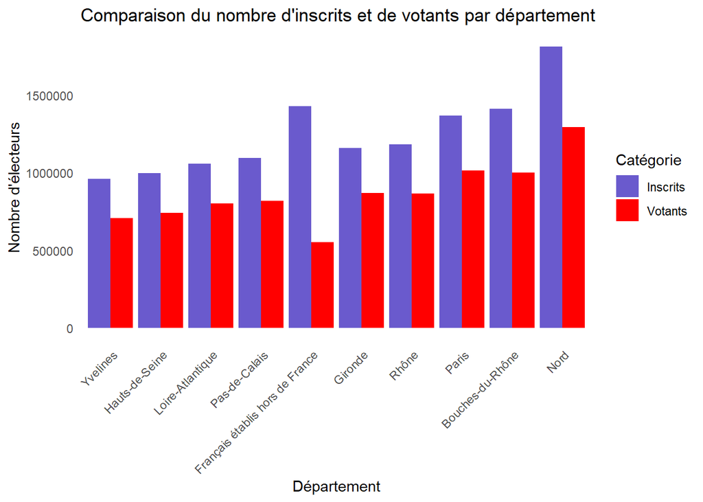

On constate que les départements du **Nord**, des **Bouches-du-Rhône** et celui regroupant les **Français établis hors de France** comptent les nombres d’inscrits les plus élevés.

Le graphique ci-dessous présente le Top 3 des départements ayant enregistré les taux d’abstention les plus élevés, en considérant la **France entière** d’une part et la **France métropolitaine** d’autre part.

| Abstention 2nd Tour présidentielles 2022 France métropolitaine Département | Abstention 2nd Tour présidentielles 2022 France métropolitaine Taux | Abstention 2nd Tour présidentielles 2022 France entière ( y compris DOM-TOM ) Département | Abstention 2nd Tour présidentielles 2022 France entière ( y compris DOM-TOM ) Taux |
| --- | --- | --- | --- |
| Corse-du-Sud | 39.28 | Nouvelle-Calédonie | 65.20 |
| Haute-Corse | 39.01 | Saint-Martin/Saint-Barthélemy | 61.83 |
| Seine-Saint-Denis | 38.79 | Français établis hors de France | 61.38 |

On observe qu’en France, ce sont les départements de **Nouvelle-Calédonie**, **Saint-Martin/Saint-Barthélemy** et celui regroupant les **Français établis hors de France** qui enregistrent les taux d’abstention les plus élevés, dépassant **60 %**. En France métropolitaine, les départements de la **Corse-du-Sud**, de la **Haute-Corse** et de la **Seine-Saint-Denis** figurent parmi les moins participatifs. Par ailleurs, la figure ci-dessous montre que dans tous les départements d’outre-mer, à l’exception de **Wallis-et-Futuna**, les taux d’abstention sont supérieurs à ceux observés en métropole. Cela pourrait refléter un moindre intérêt pour les enjeux politiques dans ces territoires.

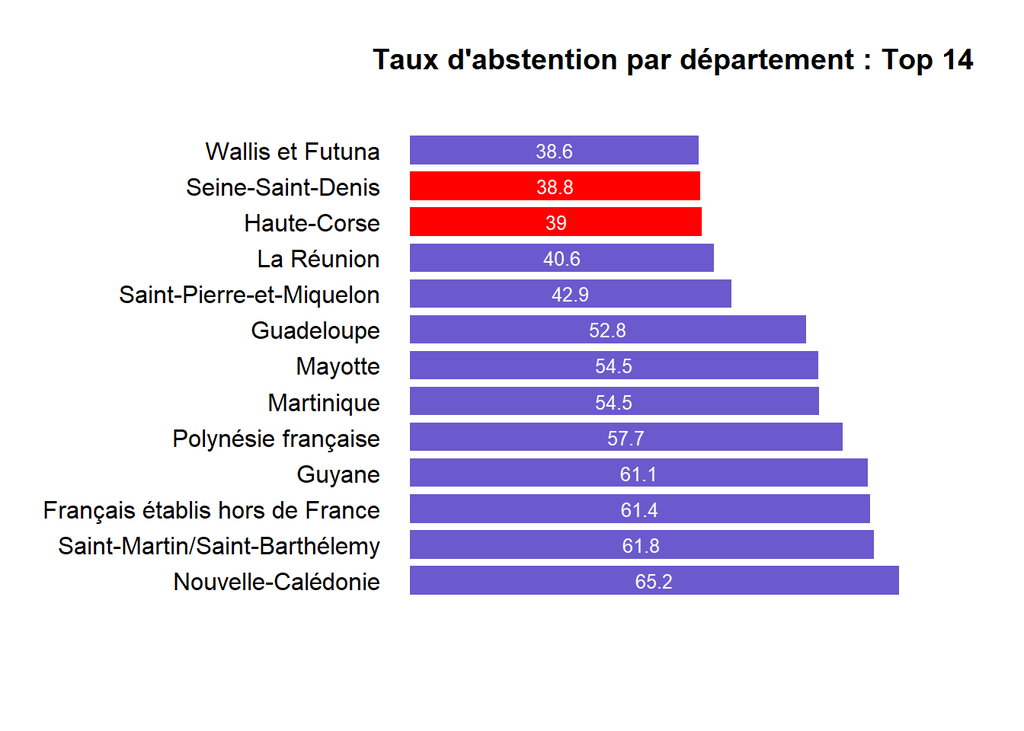

### 2.5 Analyse de la répartition des taux d’abstention dans les départements

On remarque que la répartion des taux d’abstention communale au sein des départements diffère d’un département à un autre. Le test de Kruskal-Wallis, qui permet de comparer les médianes entre plusieurs groupes, appliqué à certains départements du **Top 14** précédent met en avant ce constat. En effet, ce test appliqué aux départements de **Seine-Saint-Denis** et de **Mayotte** suggère qu’il y a des différences significatives en terme de répartition des taux d’abstention communale au sein de ces départements. A l’inverse avec une pvalue égale à *0.85* lorsqu’on considère les départements de **Seine-Saint-Denis** et de **Haute-Corse**, le test suggère qu’il n’y a pas de différences significatives entre les répartitions des taux d’abstention communale au sein de ces départements.

## 3. Analyse des voix reçus par chaque candidat

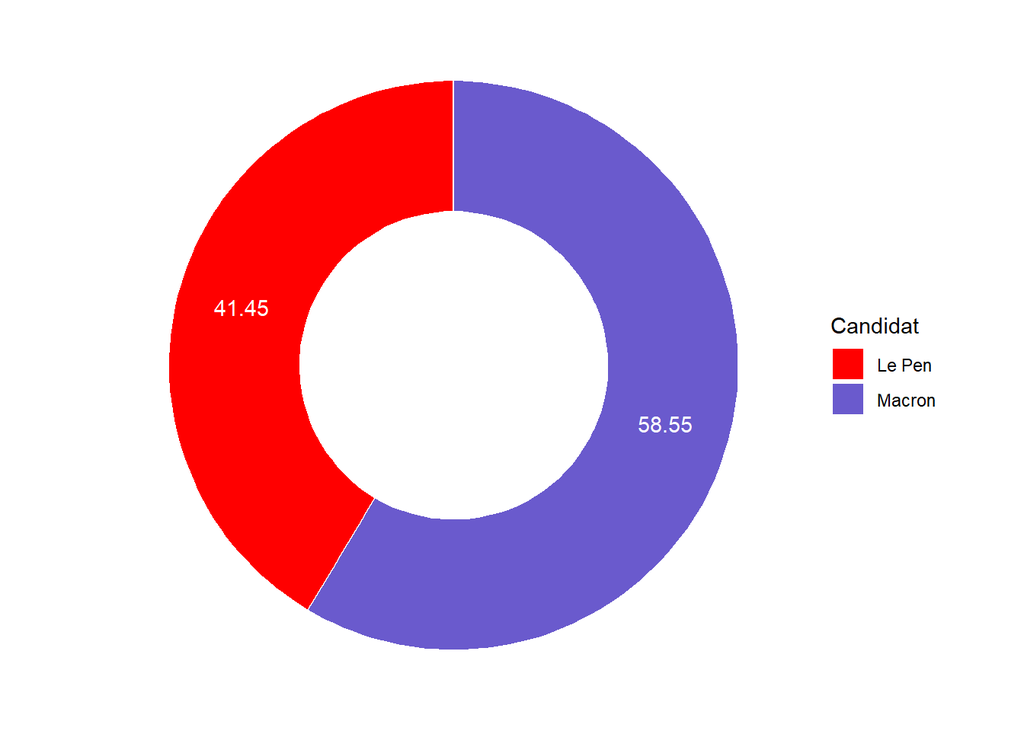

Lors de ce second tour des élections présidentielles, le candidat **Emmanuel Macron** a obtenu 58.55 % des voix exprimées et a été déclaré vainqueur. Le tableau ci-dessous présente le Top 10 des départements ayant accordé le plus de voix à chaque candidat :

| Top 10 des départements ayant voté pour Emmanuel Macron Département | Top 10 des départements ayant voté pour Emmanuel Macron % Votes reçus | Top 10 des départements ayant voté pour Marine Le Pen Département | Top 10 des départements ayant voté pour Marine Le Pen % Votes reçus |
| --- | --- | --- | --- |
| Français établis hors de France | 86.14 | Guadeloupe | 69.60 |
| Paris | 85.11 | Martinique | 60.87 |
| Hauts-de-Seine | 80.39 | Guyane | 60.78 |
| Val-de-Marne | 74.48 | Aisne | 59.91 |
| Seine-Saint-Denis | 73.72 | La Réunion | 59.56 |
| Yvelines | 71.05 | Mayotte | 59.10 |
| Ille-et-Vilaine | 70.94 | Corse-du-Sud | 58.32 |
| Loire-Atlantique | 69.48 | Haute-Corse | 57.87 |
| Rhône | 68.65 | Pas-de-Calais | 57.50 |
| Finistère | 67.50 | Haute-Marne | 56.96 |

Les électeurs **français établis hors de Franc**e, ainsi que ceux de **Paris** et des **Hauts-de-Seine**, ont été les plus nombreux à voter pour **Emmanuel Macron**. En revanche, **Marine Le Pen** a reçu le plus de voix dans les départements de **Guadeloupe**, **Martinique** et **Guyane**.

### 3.1 Départements avec les plus grands écarts de voix

Le graphique ci-dessous présente les départements où l’on observe les dix plus grands écarts de votes entre les deux candidats.

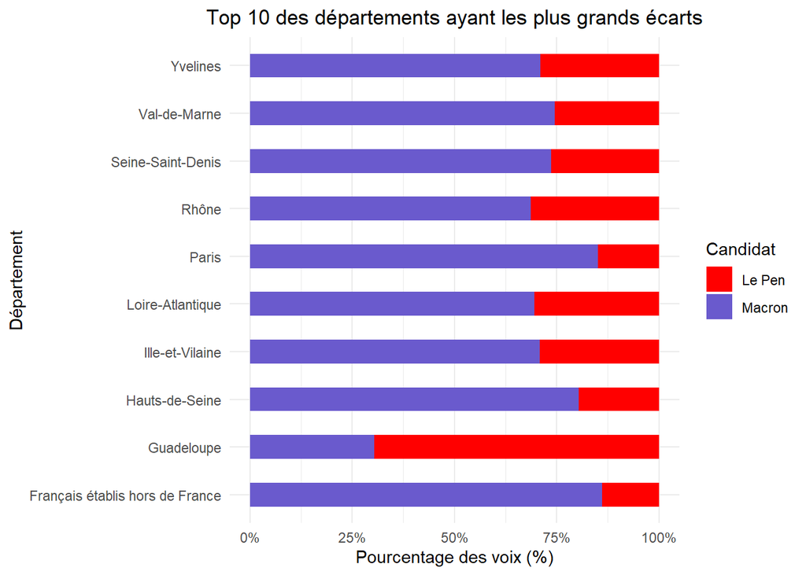

On remarque que dans le top 10 des départements où on observe les plus grands écarts de voix reçus entre les deux candidats, le candidat **Emmanuel Macron** remporte 9 départements. Le plus grand écart en sa faveur est de **72.28%** et s’observe dans le département constitué par les **Français établis hors de France** tandis que celui en faveur de **Marine Lepen** est de **39.2%** et s’obverve dans le département de **Guadeloupe**.

On constate que, parmi les 10 départements où l’on observe les plus grands écarts de voix reçues entre les deux candidats, **Emmanuel Macron** remporte 9 départements. Le plus grand écart en sa faveur est de **72.28%**, observé dans le département des **Français établis hors de France**, tandis que le plus grand écart en faveur de **Marine Le Pen** est de **39.2%**, constaté dans le département de la **Guadeloupe**.

### 3.2 Lien entre taux de participation et les voix reçus par chaque candidat

Le graphique ci-dessous présente les nuages de points des pourcentages de votes reçus par chaque candidat en fonction du taux de participation. Une analyse visuelle montre que, dans les départements ayant des taux de participation élevés (entre 70 % et 80 %), **Emmanuel Macron** sort généralement gagnant, car les pourcentages de votes qu’il reçoit sont souvent supérieurs à 50 %.

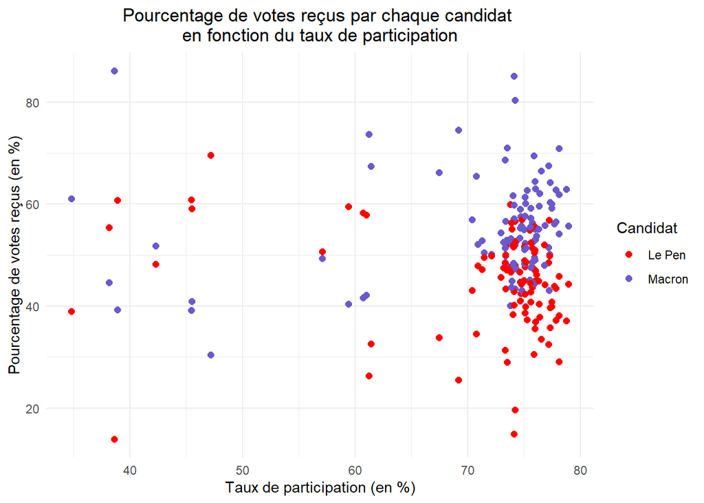

On observe une **faible corrélation linéaire négative (-0.16)** entre le **taux de participation** et le pourcentage de **votes reçus par Marine Le Pen**. Cela signifie que, à mesure que le **nombre d’électeurs diminue, le pourcentage de votes reçus par le candidat augmente**. À l’inverse, il existe une **faible corrélation linéaire positive (0.16)** entre le **taux de participation** et le pourcentage de **votes reçus par Emmanuel Macron**, indiquant que **plus le taux de participation est élevé, plus le pourcentage de votes reçus par le candidat augmente**. Cependant, cette corrélation n’est pas significative au seuil de 5 %, car la p-value associée à la statistique de test est légèrement inférieure à 0.1.

# Conclusion :

Dans cette étude, nous avons effectué une analyse des grandes tendances observées lors du second tour des élections présidentielles de 2022. Ce second tour a opposé **M. Emmanuel Macron**, candidat du parti *La République En Marche*, à **Mme Marine Le Pen**, candidate du parti *Rassemblement National*. Cette élection a été marquée par un taux d’abstention record, jamais observé pour un second tour d’élection présidentielle.